# Do open-data models vary with their training distribution?

Open-data families vs their training distribution

The main model reports that the language features explain 92% of the between-language variance but only about 20% of the model-by-language variance: *which* model struggles *where* is largely idiosyncratic. This document asks whether any of that residual is predictable from what the model was trained on, for the subset of models whose pretraining data is documented.

**What is actually available** is much thinner than “open data” suggests:

| family | English share | languages | source |
| --- | --- | --- | --- |
| OLMo 2 / 3 | ~90% | English-centric | Dolma; OLMo reports |
| EuroLLM | 50% then 32.5% | 35, listed explicitly | EuroLLM-9B report, model card |
| Apertus | ~60% | 1811 | tech report Table G.6 (FineWeb-2) |
| Gemma 3, Granite, Qwen | not published | – | – |

Only Apertus publishes anything approaching a per-language distribution, and even that is the *source corpus* (FineWeb-2) rather than the final mixture: high-resource languages are subsampled to 10% or 33%. EuroLLM gives aggregate English share plus an explicit list of supported languages, but its per-language token shares exist only as a figure. So the strongest test available is not a regression on token shares — it is EuroLLM’s documented **coverage boundary**.

```r
cells <- readRDS("../../artifacts/analysis/model_cells.rds")
cache <- function(pat) {
  f <- list.files("_cache/transfer_analysis", pattern = pat, full.names = TRUE)
  f <- f[grepl("[.]RData$", f)]
  e <- new.env(); load(f[order(file.mtime(f), decreasing = TRUE)][1], envir = e); e
}
fit <- cache("^fit-lme4_")$fit_main

## The model-by-language random effects are the right outcome here: they are what
## is left of a model's performance in a language AFTER model ability, language
## difficulty and the three language features are accounted for. Using raw
## accuracy instead would confound coverage with the fact that English-centric
## models also tend to be the weaker ones.
re <- ranef(fit)$`model:language`
ml <- tibble(key = rownames(re), effect = re[, 1]) %>%
  separate(key, into = c("model", "language"), sep = ":", extra = "merge") %>%
  left_join(cells %>% distinct(model, family) %>% mutate(across(everything(), as.character)),
            by = "model")

eurollm <- read.csv("eurollm_coverage.csv")
apertus <- read.csv("apertus_fineweb2.csv")
cat(nrow(ml), "model x language effects |", n_distinct(ml$family), "families\n")
```

```
## 690 model x language effects | 9 families
```

# EuroLLM: the coverage boundary

EuroLLM-9B’s card lists 35 supported languages: the 24 official EU languages plus Arabic, Catalan, Chinese, Galician, Hindi, Japanese, Korean, Norwegian, Russian, Turkish and Ukrainian. Of our 15, that covers everything **except Icelandic and Marathi**. This is a documented, pre-existing boundary rather than one drawn to fit the results.

```r
eu <- ml %>% filter(family == "EuroLLM") %>%
  left_join(eurollm, by = "language") %>%
  mutate(supported = if_else(eurollm_supported == 1, "supported", "not supported"))

eu %>% group_by(supported) %>%
  summarise(n = n(), mean_effect = round(mean(effect), 3),
            sd = round(sd(effect), 3), .groups = "drop")
```

```
## # A tibble: 2 × 4
##   supported         n mean_effect    sd
##   <chr>         <int>       <dbl> <dbl>
## 1 not supported     4      -2.2   0.507
## 2 supported        26       0.329 0.508
```

```r
eu %>% filter(language != "eng") %>% arrange(effect) %>%
  transmute(language, supported, effect = round(effect, 3)) %>% head(8)
```

```
## # A tibble: 8 × 3
##   language supported     effect
##   <chr>    <chr>          <dbl>
## 1 mar      not supported -2.83
## 2 mar      not supported -2.39
## 3 isl      not supported -1.80
## 4 isl      not supported -1.78
## 5 hin      supported     -0.445
## 6 ara      supported     -0.198
## 7 jpn      supported     -0.063
## 8 jpn      supported     -0.047
```

```r
t.test(effect ~ supported, data = filter(eu, language != "eng"))
```

```
##
##  Welch Two Sample t-test
##
## data:  effect by supported
## t = -9.8368, df = 3.6635, p-value = 0.000916
## alternative hypothesis: true difference in means between group not supported and group supported is not equal to 0
## 95 percent confidence interval:
##  -3.387081 -1.852945
## sample estimates:
## mean in group not supported     mean in group supported
##                  -2.2001967                   0.4198163
```

# Apertus: does performance track the source-corpus share?

Apertus is the only family with a per-language table. Table G.6 of the tech report gives FineWeb-2 document shares, covering 12 of our 15 languages (Icelandic and Marathi fall into “Others”; English comes from a different corpus). Because the high-resource languages are subsampled unevenly, this is a noisy proxy for the final mixture rather than a measurement of it.

```r
ap <- ml %>% filter(family == "Apertus") %>%
  inner_join(apertus, by = "language") %>%
  mutate(log_share = log10(pct_fineweb2))

ap %>% group_by(language) %>%
  summarise(pct = first(pct_fineweb2), effect = round(mean(effect), 3), .groups = "drop") %>%
  arrange(desc(pct))
```

```
## # A tibble: 12 × 3
##    language   pct effect
##    <chr>    <dbl>  <dbl>
##  1 rus      13.3   0.466
##  2 zho      12.7  -0.338
##  3 deu       9.36  0.205
##  4 jpn       8.23 -0.264
##  5 fra       7.28 -0.04
##  6 ita       4.8   0.039
##  7 nld       2.93 -0.172
##  8 ara       1.26 -0.036
##  9 ukr       1.04  0.17
## 10 dan       0.94 -0.124
## 11 hin       0.45  0.142
## 12 est       0.21  0.84
```

```r
with(ap %>% group_by(language) %>%
       summarise(log_share = first(log_share), effect = mean(effect), .groups = "drop"),
     cor.test(log_share, effect, method = "pearson"))
```

```
##
##  Pearson's product-moment correlation
##
## data:  log_share and effect
## t = -1.5901, df = 10, p-value = 0.1429
## alternative hypothesis: true correlation is not equal to 0
## 95 percent confidence interval:
##  -0.8134264  0.1679622
## sample estimates:
##        cor
## -0.4492437
```

# The Apertus English anomaly

```r
cells %>% filter(family == "Apertus") %>%
  group_by(model, language) %>%
  summarise(acc = sum(n_correct) / sum(n_total), .groups = "drop") %>%
  group_by(model) %>%
  summarise(english = round(100 * acc[language == "eng"], 1),
            non_english = round(100 * mean(acc[language != "eng"]), 1),
            gap = round(english - non_english, 1), .groups = "drop")
```

```
## # A tibble: 2 × 4
##   model                     english non_english   gap
##   <fct>                       <dbl>       <dbl> <dbl>
## 1 Apertus-70B-Instruct-2509    22.7        58.5 -35.8
## 2 Apertus-8B-Instruct-2509     25.2        30.8  -5.6
```

# Across families

```r
gap_by_family <- cells %>%
  group_by(family, model, language) %>%
  summarise(acc = sum(n_correct) / sum(n_total), .groups = "drop") %>%
  group_by(model) %>% mutate(rel = acc - acc[language == "eng"]) %>% ungroup() %>%
  filter(language != "eng") %>%
  group_by(family) %>%
  summarise(mean_english_gap = round(-100 * mean(rel), 1), .groups = "drop") %>%
  arrange(desc(mean_english_gap))
gap_by_family
```

```
## # A tibble: 9 × 2
##   family  mean_english_gap
##   <fct>              <dbl>
## 1 OLMo 2              41.7
## 2 Granite             36.9
## 3 OLMo 3              25
## 4 Qwen2.5             21.7
## 5 Gemma 3             17.1
## 6 Qwen3               14.3
## 7 Qwen3.5             12.2
## 8 EuroLLM             10.4
## 9 Apertus            -20.7
```

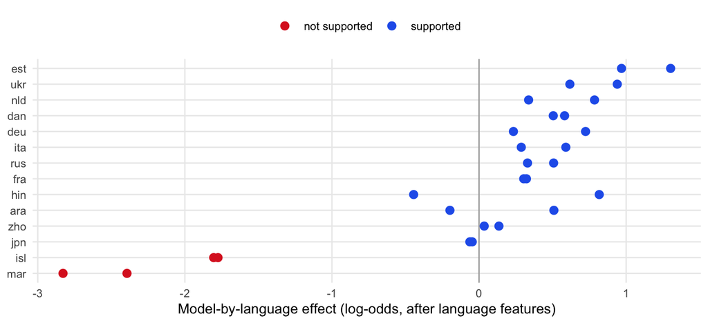

```r
eu %>% filter(language != "eng") %>%
  mutate(language = reorder(language, effect)) %>%
  ggplot(aes(effect, language, colour = supported)) +
  geom_vline(xintercept = 0, colour = "grey60", linewidth = 0.35) +
  geom_point(size = 2.4) +
  scale_colour_manual(values = c(supported = "#2563EB", `not supported` = "#DC2626"), name = NULL) +
  labs(x = "Model-by-language effect (log-odds, after language features)", y = NULL) +
  theme_minimal(base_size = 10) +
  theme(panel.grid.minor = element_blank(), legend.position = "top")
```